# The impact of firm downsizing on workers: Evidence from Ethiopia’s ready-made garment industry

World Development 176 (2024) 106412

Available online 14 December 2023 0305-750X/© 2023 Published by Elsevier Ltd.

Contents lists available at ScienceDirect

## World Development

journal homepage: www.elsevier.com/locate/worlddev

### The impact of firm downsizing on workers: Evidence from Ethiopia’s ready-made garment industry

### Morgan Hardy <sup>a</sup><sup>,</sup><sup>1</sup>, Gisella Kagy <sup>b</sup><sup>,</sup><sup>1</sup>, Eyoual Demeke <sup>c</sup><sup>,</sup><sup>1</sup>, Marc Witte <sup>d</sup><sup>,</sup><sup>1</sup>, Christian Johannes Meyer <sup>e</sup><sup>,</sup><sup>∗</sup>

a *New York University Abu Dhabi, United Arab Emirates* b *University of Wisconsin-Madison, United States of America* c *Policy Studies Institute, Ethiopia* d *IZA Institute of Labor Economics, Germany* e *University of Oxford, Nuffield College, New Road, Oxford OX1 1NF, United Kingdom*

#### A R T I C L E I N F O

*JEL classification:* I18 I12 J65 O12 D91

*Keywords:* Job displacement Trade shock Global value chains Gender Ethiopia COVID-19

#### A B S T R A C T

We analyze matched employee–employer data from Ethiopia’s largest special economic zone during a period of downsizing pressure from the COVID-19 world import demand shock. We observe substantial job displacement during the shock peak, particularly for new hires. These largely female and rural-to-urban migrants persistently ‘‘fall off the employment ladder’’, remaining unemployed both within and outside the zone even after employers have recovered from the shock. We observe high levels of urban-centered food insecurity and depression symptoms during the crisis peak, regardless of employment status. Our findings highlight the importance of social protection policies within export-oriented development strategies.

#### **1. Introduction**

In low-income countries, where self-employment and informal employment is prevalent, formal wage employment is often seen as highly desirable (Banerjee, Banerjee, & Duflo, 2011; Banerjee & Duflo, 2007; Krugman, 1997). Structural transformation through the promotion of foreign direct investment in export-oriented manufacturing industries and global value chain integration is thus a policy priority of governments and development partners around the world (Oqubay, 2019;

∗Corresponding author.

*E-mail addresses:* morgan.hardy@nyu.edu (M. Hardy), gikagy@vassar.edu, gkagy@wisc.edu (G. Kagy), eyoual.tamrat@psi.gov.et (E. Demeke), witte@iza.org (M. Witte), christian.meyer@nuffield.ox.ac.uk (C.J. Meyer).

1 The authors’ names are in certified random order. We thank without implicating Tirsit Endrias, Andrew Foster, Kamila Hamza, Kathie Krumm, Koen Maaskant, Fekadu Nigussie, Victoria Strokova, and Robert Chase for assistance and helpful comments and Fatahun Yonas for the partnership and cooperation on our broader project. Seminar participants at Oxford, the World Bank, STEG, LACDev, PSE, and IZA provided helpful comments. We also thank our field team led by Stephanie Annijas and Endale Gebre Gebremedhine, without whom this work would not be possible. Valentina Antonaccio, Daniela Villacreces Villacis, and Anne Schick provided excellent research assistance. We gratefully acknowledge funding by the UK Foreign, Commonwealth & Development Office (FCDO) through the World Bank Group ‘‘More, better, and more inclusive jobs: Preparing for successful industrialization in Ethiopia’’ initiative, the World Bank Development Impact Evaluation (DIME) ieConnect for Impact Program, the International Growth Centre (IGC), and the CEPR/FCDO Private Enterprise Development in Low-Income Countries (PEDL) initiative. Fieldwork received ethical approval from the University of Oxford Economics Department Research Ethics Committee (protocol #ECONCIA21-21-12). All errors are our own.

World Bank Group, 2020). In Ethiopia, such an export-oriented industrialization strategy has created formal, low-skill wage jobs for nearly 86,000 workers, most of them in special economic zones focused on the ready-made garment (RMG) industry.

The existing evidence on the effects of low-skill wage employment on worker welfare is mixed. Previous research has found positive impacts in the form of delayed marriage and childbirth for women (Heath & Mobarak, 2015), increased bargaining power and income (Atkin, 2011; Getahun & Villanger, 2018; Majlesi, 2016), but also

https://doi.org/10.1016/j.worlddev.2023.106412

2

*M. Hardy et al.*

decreased educational attainment (Atkin, 2016) and increased selfreported health problems (Blattman & Dercon, 2018). These existing studies focus on identifying impacts of expansion in low-wage employment opportunities. What is less well understood is what happens to workers when these opportunities contract.

Our analysis leverages a unique combination of survey and administrative data from HIP that covers the period immediately prior to, during, and following the large drop in world import demand for ready-made garments during the spring of 2020. We designed and fielded a matched employee–employer panel survey with three waves of data on a representative sample of workers and two waves of data on the universe of all employers. To empirically quantify the ‘downsizing pressure’ documented in this paper, we match our survey with transaction-level administrative data on employer exports and world imports. This enables the calculation of a trade shock measure for each employer in our sample and a weighted average for the entire sample. We combine this data to conduct a descriptive, non-causal analysis of worker employment and welfare outcomes during this period of downsizing from January 2020 to January 2021.

We find that during the initial peak of the crisis in early 2020, overall employment in HIP was 17 percentage points lower than employerreported pre-crisis turnover expectations. This downsizing is largely driven by more recently hired workers, who are almost exclusively rural-to-urban female migrants. After 12 months, overall employment rates for workers who have worked in HIP for more than one year almost fully recover and are in line with average turnover before COVID-19. Workers hired less than a year ago appear to have persistently fallen off the employment ‘‘ladder’’; these workers not only drop out of industrial employment in HIP, but largely fail to search for and find employment opportunities outside of HIP. For all workers in HIP, we see higher rates of depression symptoms and urban-centered food insecurity during the peak of the crisis. Importantly, these adverse welfare outcomes do not appear to differ by employment status.

The key advantage of our paper lies in the uniqueness of our data, both in terms of sample and timing. The large empirical literature in economics that studies the effects of job displacement on worker

2 The analysis presented here significantly expands on an earlier study (Meyer et al., 2020), which only used data from the spring 2020 shock, with two additional rounds of data and comparisons to employer reported employment counterfactuals and world import demand shocks.

outcomes almost exclusively comes from high-income countries (with comprehensive administrative data) and often focuses on male workers (Couch & Placzek, 2010; Jacobson, LaLonde, & Sullivan, 1993; Lachowska, Mas, & Woodbury, 2020).<sup>3</sup> Notably, we are not aware of any quantitative evidence from low-income country labor markets — a key gap which our paper fills.

Our findings also provide direct evidence on the gender-specific impacts of COVID-19 in a low-income country context. A plethora of studies suggest gender-specific impacts of the pandemic (Alon, Doepke, Olmstead-Rumsey, & Tertilt, 2020; De Paz Nieves, Gaddis, & Muller, 2021; McKinsey Global Institute, 2020; Miguel & Mobarak, 2021; O’Donnell, Buvinic, Bourgault, & Webster, 2021), though direct survey evidence is limited. Real-time surveys from high-income countries have shown that women are more affected by the crisis, including because they have to take on more childcare duties when working from home (Adams-Prassl, Boneva, Golin, & Rauh, 2020). This paper provides a complementary perspective on gender-differential effects from a sector that has received significant attention due to its potential to increase female labor force participation in low-income countries, and from a context where labor market institutions, employment relationships, and occupational choices are fundamentally different from high-income countries.

The remainder of this paper is structured as follows: Section 2 introduces our study context. Section 3 summarizes our data and empirical strategy. Section 4 presents our descriptive results. Section 5 concludes and discusses policy implications.

#### **2. Context and project overview**

*2.1. Industrialization in Ethiopia*

Over the past decade, the government of Ethiopia has set up special economic zones, ‘‘industrial parks’’, across the country to promote export-oriented light manufacturing and encourage structural transformation of the economy.<sup>4</sup> Through tax holidays and readily available physical infrastructure, the government has particularly targeted foreign direct investment (FDI) in the RMG industry and other light manufacturing. Before the COVID-19 pandemic hit, firms across all industrial parks employed about 86,000 workers. RMG exports accounted for about one third of Ethiopia’s exports in 2020.

This study is set in the government’s flagship industrial park located in the city of Hawassa, in Ethiopia’s Southern Nations, Nationalities and People’s Region (SNNPR). In January 2020, almost 28,000 workers from the wider region were employed by 20 different firms in HIP. At full capacity, HIP could provide employment to 60,000 workers. Like in all of Ethiopia’s industrial parks, production worker jobs in HIP are permanent, salaried full-time positions with formal contracts.<sup>5</sup> Notably, all HIP workers are hired and matched to firms through a central system, which produces quasi-random worker–firm matches. On any given day, job seekers who satisfy minimum age and education requirements can come to an office within HIP, where they undertake a series of aptitude tests. Upon passing, they are allocated to a firm according to all firms’ centrally submitted requests for additional workers. Firms and jobs are allocated on a ‘‘first-request, first-serve’’ basis. This implies that any worker’s initial firm match is determined through the relative timing of the worker’s job application and the firm’s request for additional labor,

3 Beyond large and persistent impacts on employment and earnings, this literature has found impacts on mental health, (Classen & Dunn, 2012; Salm, 2009; Schmitz, 2011), physical health (Browning & Heinesen, 2012; Eliason & Storrie, 2009b), long-run consumption (Browning & Crossley, 2008), and mortality (Eliason & Storrie, 2009a).

4 The text in this section is a shortened and adapted version of a description in Meyer et al. (2020).

5 Maaskant, Meyer, and Krkoska (2020) provide a description of worker compensation in Ethiopia’s industrial parks.

3

*M. Hardy et al.*

rather than firm or employee specific choices made by either party. The initial worker–firm assignment is permanent for 90 percent of workers.

The production workers who account for the bulk of employment in Hawassa and the broader RMG industry in Ethiopia are predominantly female and tend to be young, low-skill, recent rural–urban migrants with little to no previous work experience.<sup>6</sup> As migrant workers, they may also have a less robust local safety net and find it more difficult to access public services including the government’s safety net programs. Given their lack of insurance options, they are particularly vulnerable to economic shocks. Section 3.1 below summarizes our study sample.

*2.2. Job losses in Ethiopia’s RMG industry due to the COVID-19 pandemic*

Global retail sales of ready-made garments collapsed during the initial phase of COVID-19 related lock-downs in March 2020. In the United States, monthly sales of clothing and clothing accessory retail stores fell by almost 90 percent between February and March 2020.<sup>7</sup>

As a result, orders in the RMG industry were frozen or canceled: In a survey of all firms in Ethiopia’s special economic zones conducted contemporaneously between May and July 2020, more than 75 percent of firms reported experiencing lower sales and lower production volumes than they had planned before the crisis. For firms that reported a decline in sales, average sales decreased by 57 percent; for firms that reported a decline in production, average production volumes decreased by 56 percent (Mengistu et al., 2020).

Spring 2020 also saw a rapid increase in COVID-19 cases globally and in Ethiopia. Importantly, however, the official number of confirmed COVID-19 cases in Hawassa remained zero throughout the data collection period. The government of Ethiopia never ordered businesses or factories to close. Along with several other measures to stop the spread of COVID-19 and to support the economy, the government instead announced that private employers were not allowed to terminate workers during a five-month State of Emergency starting April 2020 and ending in September 2020.<sup>8</sup> Firms in Hawassa Industrial Park reacted by temporarily suspending operations and putting workers on paid and unpaid leave.<sup>9</sup> In Meyer et al. (2020), it is documented that among an all-female sample of workers employed in January 2020, 41.4 percent have experienced a change in their employment status by July 2020: 19.8 percent were placed on paid leave, 6 percent on unpaid leave, 13.1 percent left voluntarily, and 2.4 percent reported being terminated. The low proportion of respondents that reports being formally terminated reflects the government ban on firing during the crisis and likely represents a lower bound for total layoffs. In addition, indefinite unpaid leave cannot always clearly be delineated from a formal termination in this context. In the remainder of the paper, we thus group respondents that report having been terminated, those who have voluntarily left, and those who have been placed on unpaid leave. Our findings are robust to only considering respondents who report being terminated or respondents who report either being terminated or having left voluntarily.

6 See also Girum, Buehren, and Goldstein (2020) and Meyer (2020) for a description of workers in Ethiopia’s RMG industry.

7 Based on US Census Bureau Advance Monthly Retail Trade data (Clothing and Clothing Accessory Stores).

8 See ‘‘Proclamation 3/2020 – State of Emergency Proclamation Enacted to Counter and Control the Spread of COVID-19 and Mitigate Its Impact’’, available from https://www.ilo.org/dyn/natlex/natlex4.detail?p_lang=en&p_ isn=110046&p_count=26&p_classification=01 (accessed August 3, 2020).

9 The ILO BetterWork initiative reported in April 2020 that about 14,000 workers in Hawassa Industrial Park, about half of all production workers, have been asked not to work (https://betterwork.org/2020/04/15/ethiopiaupdates/, accessed August 3, 2020).

*2.3. Ethiopia’s civil conflict and impacts on the RMG industry*

Looking ahead beyond the time period discussed in this paper, the Ethiopian civil conflict has impacted the country’s RMG industry and the government’s broader industrialization strategy. With the deterioration of the conflict in November 2020, several industrial parks and other production sites were forced to suspend operations. Firms located in the Tigray region were particularly affected.<sup>10</sup>

Direct impacts of the conflict on firm operations aside, the broader business environment for Ethiopia’s RMG industry deteriorated throughout 2021. In November 2021, the US government under President Biden announced that it would suspend Ethiopia from the African Growth and Opportunity Act (AGOA) citing human rights violations in the conflict. AGOA enables duty-free access to the US market for almost all of Ethiopia’s exports including ready-made garments. AGOA had been most recently renewed in 2015 and was originally set to expire in 2025. In 2020, Ethiopia’s exports to the United States under AGOA totaled $238 million (45 percent of total Ethiopian exports to the US), and $219 million of these exports were from the garment industry alone (Naumann, 2021). Two weeks after the suspension of AGOA was announced, a major clothing brand stated its intent to terminate its operations at Hawassa Industrial Park citing safety concerns.

While it is difficult to estimate the exact number of jobs at risk in Ethiopia’s RMG industry due to the suspension of AGOA, we hope that our analysis of the COVID-19 trade shock in HIP can illustrate potential implications of the ongoing conflict for firms and workers.

#### **3. Data and sampling**

The main analysis of this paper uses matched employee–employer survey data that spans the period from the March 2020 to January 2021. We complement this with employer survey data and administrative data on employer exports and global trade volumes to quantify the exposure of employers to changes in global trade. This section describes sources and methods of data collection.

*3.1. Worker survey data*

Our data on individual workers in HIP come from a three-round panel phone survey designed by our team and implemented by a professional survey firm on behalf of the researchers and the World Bank. We worked closely with local stakeholders including the federal government, the local government, and the investors association of HIP to field the survey.

*Survey sampling strategy.* Our survey aimed to obtain a representative sample of workers in HIP in January 2020 before the pandemic unfolded. The sampling frame for the survey was based on an electronic personnel database that includes the universe of production workers and applicants.<sup>11</sup> We use all records of ever-employed workers in this database as of April 15, 2020. We then contact phone numbers based on a random rank.<sup>12</sup> Workers from the personnel database were included

10 For example, a factory near Mekelle, Tigray, owned by Bangladeshi garment maker DBL was hit and damaged by a rocket attack in late November 2020 (Paul, Ringstrom, & Bavier, 2020). 11 Prior to the data collection effort described in this paper, some of the authors worked with local stakeholders to assist in setting up this personnel database. It covers all individuals who ever applied for a production job in HIP and includes information on their contact details, basic demographic characteristics, and initial worker–firm match. New entries into the database are deduplicated using biometrics. The database does not capture reliable information on exits from HIP employment.

12 If we do not reach the person indicated in the database but another contact (e.g. in the case of shared phones), we attempt to obtain updated contact information for the person in the database.

4

*M. Hardy et al.*

in our study if (1) we were able to reach them using the phone number listed in the database or provided by another contact within 15 call attempts; (2) they verbally confirmed that they were working in HIP on or after 1 January 2020; (3) we were able to obtain information on the current or last employer they worked for. This sampling strategy implies that our sample contains only individuals that were working in the industrial park at the beginning of the calendar year 2020 or afterwards; it does not include individuals who unsuccessfully applied for employment in HIP. The study sample analyzed in this paper is restricted to 1,883 respondents who we were able to reach for all three rounds of the survey. While there is attrition from our survey over the three rounds of data collection, we find that neither employment status nor an interaction of employment status with five key heterogeneity dimensions are significant predictors of attrition (Appendix Table A3).<sup>13</sup>

*Survey design.* We survey workers at three points in time: during the first peak of the crisis (spring 2020), amidst an initial recovery from the crisis (fall 2020), and a year after the beginning of the crisis (January 2021).<sup>14</sup> The target call date was randomized over respondents within each of the three rounds. During all three rounds of the survey we collected information on employment inside and outside of HIP, food security, current location, and mental health. During the first survey (spring 2020), we collected basic demographics, including worker gender, education, an indicator for whether they have a community (‘‘kebele’’) ID card from Hawassa. During the last round of the survey (January 2021), we additionally included a retrospective 13 month panel that collected monthly information on the individual’s park employment status.

*Main outcomes and heterogeneity dimensions.* We consider five main worker outcomes: Employment in HIP, employment outside of HIP, if the individual is still currently located in Hawassa, if the individual reports to experience food insecurity, and if the individual screens positive for depression symptoms. We consider a person to be food insecure based on the following question: ‘‘In the past 7 days, did you worry that you personally would not have enough food’’. To determine if an individual screens positive for depression symptoms, we use the 2-item version of the Patient Health Questionnaire (PHQ-2). PHQ-2 is a commonly used, quick, self-administered diagnostic tool to detect depressive disorders (Kroenke, Spitzer, & Williams, 2003). It is important to note that the purpose of this instrument is not to establish a diagnosis or to monitor depression severity, but to act as a first step in screening patients. Kroenke et al. (2003) recommend that patients who score greater or equal than 3 on PHQ-2 are more likely to suffer from a depressive disorder and should be further evaluated with the other diagnostic instruments or direct interview to determine whether they meet criteria for a depressive disorder. We use the same suggested cut-off point in this paper.<sup>15</sup> Key respondent heterogeneity dimensions are gender, an indicator for whether they are recent rural–urban migrants, an indicator for having completed secondary education (which is also the median and mode of completed education), an indicator for having tenure in HIP for longer than 12 months, and an indicator for job type. We classify respondents as recent rural–urban migrants if they do not have a local community (‘‘kebele’’) identification card.

13 We do find that respondents in supervisor jobs are significantly more likely to attrit from our panel in rounds two and three if they also faced an employment losses in round one.

14 Each survey takes on average 12 min to complete. The survey received ethical approval from the University of Oxford Economics Department Research Ethics Committee (protocol #ECONCIA21-21-12). An English translation of our survey instrument is available online at osf.io/wxdhj.

15 PHQ-2 has been validated among Ethiopian adults (Gelaye, Wilson, Berhane, Deyessa, Bahretibeb, Wondimagegn, Shibre Kelkile, Berhane, Fann, & Williams, 2016; Hanlon, Medhin, Selamu, Breuer, Worku, Hailemariam, Lund, Prince, & Fekadu, 2015).

Respondent tenure is calculated from the electronic personnel database and measured from January 1, 2020. Job type is split between line workers (including machine operators, quality checkers, and janitorial staff) and supervisors.

*Profile of the sample and comparison with population.* Our study sample is highly similar to the full sample of all respondents ever interviewed and the electronic personnel database ( Table A1). On average, individuals in the study sample are 22 years old, have 10 years of education, are rarely married, and are almost all from Ethiopia’s SNNP region. We can also compare our study sample to the population at large using public microdata from the Living Standards Measurement Study/Ethiopia Socioeconomic Survey (ESS/LSMS) 2015–2016. Individuals in the study sample, ever interviewed sample, and personnel database are younger, significantly more educated, and less likely to be married than those from the population at large.

*3.2. Employer survey data*

*3.3. Administrative data on employer exports and global imports*

To describe the external environment for employers in our sample, we use employer export transactions and global trade data to construct an employer-level measure of downsizing pressure based on world import demand. This measure is a weighted average of a common set of shocks, with weights reflecting heterogeneous shock exposure of each employer. This method follows Hummels, Jørgensen, Munch, and Xiang (2014).

NOTE: contains mathematical notation; text above is the PDF text layer and symbols may be mis-extracted. Image shows the original.

NOTE: contains mathematical notation; text above is the PDF text layer and symbols may be mis-extracted. Image shows the original.

#### **4. Empirical analysis**

In this section, we present a set of empirical findings characterizing employee outcomes before, during, and after the global trade shock. After describing sample characteristics and quantifying the employment contraction at the core of this paper, we analyze the data from two perspectives: In Section 4.3, we first describe whose employment is most responsive to the downsizing pressure. In Section 4.4 we then present correlational evidence on the outcomes of workers during and after the downsizing peak in the spring of 2020.

*World Development 176 (2024) 106412*

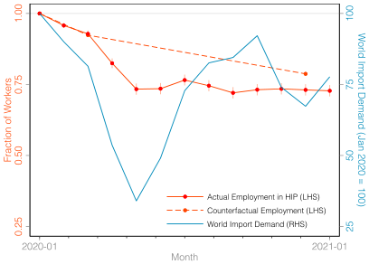

NOTE: figure/graphic rendered as an image from the PDF; its content is not machine-readable text. Caption (if any) follows as the next block.

5

*M. Hardy et al.*

**Table 1** Summary statistics and correlations for worker and employer characteristics.

[output not shown]

NOTE: table converted from PDF layout to HTML text; cell boundaries are reconstructed. See PDF if exact alignment matters.

*Notes: Male* is a variable that takes the value 1 if the person is male and 0 otherwise. *More Educated* is equal to one if an individual has above the median education level. *Long Tenure* is equal to one if an individual has been employed in HIP for more than 12 months as of January 1, 2020. *Better Management* is equal to one if the firm an individual worked/works for has an above median MOPS score. *Hawassa ID* is a binary variable that takes the value of 1 if the person has a Hawassa Kebele Identity Card and zero otherwise. *Supervisor* is a variable that takes the value 1 if the worker is a supervisor and zero if he/she is an operator. ****𝑝<* 0.01, ***𝑝<* 0.05, **𝑝<* 0.1.

*4.1. Sample characteristics*

Table 1 presents summary statistics and bivariate correlations for key employee and employer characteristics introduced in Section 3.1.

Overall, levels of correlations between our key characteristics of interest are statistically significant but not always economically substantial. We cautiously interpret some dimensions as somewhat independent because we believe that this yields important, policy-relevant insights into the situation of workers in our sample. However, we also note that our analysis of any worker characteristic is endogenous both to other observed characteristics as well as unobservables not discussed or collected.

*4.2. Downsizing in hawassa industrial park: Initial shock and recovery in world trade*

We begin our empirical analysis by illustrating the contraction in HIP employment that is at the core of this paper. For the period between January 2020 and January 2021, Fig. 1 shows actual HIP employment rates (solid line with circle markers) against a counterfactual based on expected normal turnover rates reported by employers (dashed line with circle markers). We overlay our measure of the employer-specific ‘‘downsizing pressure’’ — the world demand for the products exported by the employers in our sample (solid line without markers).

**Fig. 1.** Actual Employment in Hawassa Industrial Park, Employment Counterfactual without COVID-19 Shock, and World Import Demand. *Notes:* Actual employment is the average employment across all workers in our sample, calculated from the 13 month retrospective panel administered in January 2021. Counterfactual employment is calculated from a pre-crisis estimate of regular worker turnover based on firm manager responses in our firm survey. World import demand (WID) measures the global demand for products of firms operating in Hawassa Industrial Park (HIP), following Hummels et al. (2014).

*4.3. Differences in HIP employment rates by worker and firm characteristics*

In this subsection, we describe who in our sample is impacted by the contraction and recovery in HIP employment throughout 2020. We focus on the six dimensions of worker, job, and employer heterogeneity that we describe in Section 3.1. Fig. 2 plots the fraction of workers employed in HIP by these categories over the year. We use monthly data from our retrospective employment panel.

Across all heterogeneity dimensions, we see a large decrease in HIP employment during the peak global trade shock. This initial drop in employment is larger for workers that have been employed for less than a year (panel d), recent rural–urban migrants (panel c), and those workers in lower-level, production jobs versus those that are in higherranked positions (panel e). We also see that workers in firms with better management practices are experiencing a steeper initial drop (panel f). This steep initial drop is explained by an association of firm management practices with workers being quickly put on paid leave during the onset of the crisis (Figure A1). This different crisis handling by better managed firms may also explain the faster recovery of employment in those firms after the initial peak. Notably, there are no longer-run differences in employment by firm management practices. Employment in HIP also recovers more quickly for less educated workers. In fact, we see that workers with more education are less likely to remain employed after the peak. Interestingly, we see no detectable differences in employment either during or post peak by gender. The largest and most persistent difference in employment drops comes from tenure

*World Development 176 (2024) 106412*

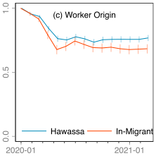

NOTE: figure/graphic rendered as an image from the PDF; its content is not machine-readable text. Caption (if any) follows as the next block.

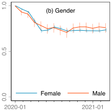

NOTE: figure/graphic rendered as an image from the PDF; its content is not machine-readable text. Caption (if any) follows as the next block.

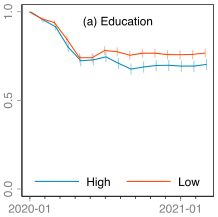

NOTE: figure/graphic rendered as an image from the PDF; its content is not machine-readable text. Caption (if any) follows as the next block.

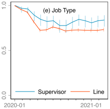

NOTE: figure/graphic rendered as an image from the PDF; its content is not machine-readable text. Caption (if any) follows as the next block.

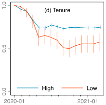

NOTE: figure/graphic rendered as an image from the PDF; its content is not machine-readable text. Caption (if any) follows as the next block.

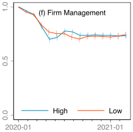

NOTE: figure/graphic rendered as an image from the PDF; its content is not machine-readable text. Caption (if any) follows as the next block.

6

*M. Hardy et al.*

**Fig. 2.** Employment in Hawassa Industrial Park by Worker and Firm Characteristics. *Notes:* Using data from the retrospective monthly survey, these figures plot the share of employed workers in Hawassa Industrial Park (HIP) over time, by worker education level, worker gender, worker worker origin, worker tenure in HIP, worker job type, and firm management practices. High (low) education is defined as worker education level above (below) the worker median education level. High (low) tenure is defined as employment in HIP for more (less) than 12 months as of January 1, 2020. Job type is split between line workers (including machine operators, quality checkers, and janitorial staff) and supervisors. High (low) firm management is defined as a Management and Organizational Practices Survey (MOPS) (Buffington et al., 2017) score above (below) the median score in the sample. 95% confidence intervals are shown in each month.

heterogeneity, suggesting that employers may employ a ‘‘last in, first out’’ rule in response to the shock.

It is important to note that these differences in employment rates during the initial peak are not driven by differential downsizing pressure of different employers (Figure A2). We see no differences in the initial shock, but we do see differences in downsizing pressure during the recovery by gender and firm management practices.<sup>16</sup>

*4.4. Differences in worker outcomes by employment status*

In this subsection, we present correlational evidence on the outcomes of workers that have been affected by downsizing versus those that have not. We structure the discussion using a simple regression of employee outcomes on indicators for HIP employment before and after the peak of the crisis in the spring of 2020. Using the three waves of our employee survey, we estimate for each employee *𝑖*in wave *𝑡*the following specification:

*𝑦𝑖,𝑡*= *𝛼*+ *𝛽*1*𝑑𝑖,𝑡*+ *𝛽*2*𝑝𝑡*+ *𝛽*3*𝑑𝑖,𝑡𝑝𝑡*+ *𝛽𝛾𝛾𝑡*+ *𝜖* (1)

NOTE: contains mathematical notation; text above is the PDF text layer and symbols may be mis-extracted. Image shows the original.

where *𝑦*is a employee-level outcome, *𝑑*is an indicator that is one if an employee is not in employment in HIP, *𝑝*is an indicator for

16 Better managed firms export to higher-income markets, relative to their less well managed counterparts. While the initial trade shock was relatively uniform, the global recovery was more heterogeneous across destination markets as consumers shifted to online purchases and countries were differentially impacted by the pandemic. We interpret the gender difference in recovery as largely driven by an underlying correlation between worker gender and management practices, where better managed firms appear to employ a larger share of women (due to the fact that they are larger and employ a larger share of line-level workers more generally).

the two post-peak survey waves, and *𝛾*is a survey wave dummy.<sup>17</sup>

Table 2 reports ordinary least-squares (OLS) estimates from Eq. (1) with standard errors clustered at the employee level.<sup>18</sup>

Overall, we find that employment outside the HIP is only 15 percentage points (PP) higher for those who have lost employment and only 11 PP higher during the initial peak trade shock. We find a strong relationship between losing employment in HIP and migration from the city of Hawassa to rural areas, again particularly during the initial peak shock. As described in Meyer et al. (2020), self-reported food insecurity is very high during the peak shock period. These high levels of food insecurity decrease to nearly half after the peak. A similar pattern holds for depression symptoms. Notably, we do not see significant differences in depression symptoms by HIP employment.<sup>19</sup> Although overall food insecurity is negatively associated with HIP employment, this is entirely explained by the differences in out-migration to less food-insecure rural areas by respondents not working in HIP (cf. Appendix Table A2).

17 Note that in this context, all combinations of employment status in HIP, location in Hawassa, and work outside of HIP are plausible and empirically observed.

18 Note that results presented are robust to the inclusion of controls for employee gender, education, tenure, and Hawassa ID.

19 While we caution against over-interpreting the level of respondents that report depression symptoms given our non-clinical measure, we note that the correlational patterns that we document resemble existing descriptive evidence from Ethiopia and high-income countries (Porter, Favara, Hittmeyer, Scott, Jiménez, Ellanki, Woldehanna, Duc, Craske, & Stein, 2021; Witteveen & Velthorst, 2020). Importantly, data from European countries indicates that losing income and/or employment during the peak of the pandemic almost doubled the risk of feelings of depression. Additionally, a sense of economic hardship during the peak of the crisis (even in the absence of job loss) appears to be correlated with decreased mental health.

7

*M. Hardy et al.*

**Table 2** Worker outcomes by HIP employment status & time.

[output not shown]

NOTE: table converted from PDF layout to HTML text; cell boundaries are reconstructed. See PDF if exact alignment matters.

*Notes:* This table reports OLS estimates from equation one. The odd numbered columns regresses the variable of interest only on the variable *Not working in HIP*. The even columns also include the variables *Post Peak* and the interaction of *Not working in HIP* and *Post Peak* to assess the immediate impact of the shock. All of the columns include time fixed effect dummies. Outcomes considered are an indicator for employment outside of HIP, current location being in Hawassa, an indicator for being food insecure, and an indicator for screening positive for depression. Standard errors are clustered at the worker level. ****𝑝<* 0.01, ***𝑝<* 0.05, **𝑝<* 0.1

Just as employment loss may be associated with different employee outcomes across time, these correlations may also vary by worker, job, or employer characteristics. We test for such differences across our key heterogeneity dimensions using the following specification:

*𝑦𝑖,𝑡*= *𝛼*+ *𝛽*1*𝑑𝑖,𝑡*+ *𝛽*2*ℎ𝑖*+ *𝛽*3*𝑑𝑖,𝑡ℎ𝑖*+ *𝛽𝛾𝛾𝑡*+ *𝜖* (2)

NOTE: contains mathematical notation; text above is the PDF text layer and symbols may be mis-extracted. Image shows the original.

where *𝑦*is a employee-level outcome, *𝑑*is an indicator that is one if an employee is not in employment in HIP, *ℎ*is an indicator for a particular heterogeneity group of interest, and *𝛾*is a survey wave dummy. Table 3 reports OLS estimates from Eq. (2) with standard errors clustered at the employee level.

Second, more educated workers (panel a, column 7), workers in supervisor positions (panel b, column 7), and workers with longer tenure in HIP (panel b, column 3) experience significantly lower levels of food insecurity. However, only supervisors retain this food security advantage in the face of HIP employment loss.

Third, non-migrant workers are predictably both less likely to outmigrate to rural areas in response to HIP employment loss and more likely to be in Hawassa, where they experience higher food insecurity regardless of HIP employment status.

Fifth, we see no significant differences in depression symptoms between those with and without HIP employment by worker, employer, and employment characteristics (panel a, columns 4, 8, and 12; panel b, columns 4, 8, and 12).

#### **5. Conclusion and policy implications**

The descriptive results presented above point to a set of patterns that can inform the design and targeting of potential policy responses to support workers on the margins of global value chains during, before, and after global trade shocks.

First, the contraction of employment in our context is largely driven by more recently hired workers, who are almost exclusively rural-tourban female migrants. Effects on them appear both large and persistent. For those workers, targeted insurance schemes such as temporary wage subsidies could play an important (and understudied) role in mitigating adverse impacts.<sup>20</sup> As our data illustrates, ensuring that such schemes are gender-sensitive and cover people that move between rural and urban areas is a particular concern in our context, where the Rural and Urban Productive Safety Net Programs (PSNP) remain largely disconnected. An appropriate social protection response in the context of this study would not only have ensured coverage of rural–urban migrant workers, but also enabled these workers to use temporary migration back to rural areas as a coping strategy.

Second, looking at welfare outcomes of workers, we find widespread reports of food insecurity and a high incidence of depression symptoms during the peak of the crisis. Notably, the incidence of depression symptoms does not appear to vary by employment. Similarly, employment does not appear to be the key driver behind the food insecurity of all respondents: While food insecurity is negatively associated with employment, this correlation is entirely explained by the differences in out-migration to less food-insecure rural areas by respondents not working in HIP. This highlights the importance of social protection and psychosocial support programs that do not depend on the employment situation of individuals.

We believe that our findings have external validity beyond the time period and context covered by our data. With Ethiopia’s loss of AGOA access in late 2021, the workers in our study faced another substantial trade shock with likely adverse welfare impacts. For other countries looking to embark on development and employment promotion strategies focused on global value chain integration through export-oriented manufacturing, our findings highlight the potential role of ‘‘adaptive’’ or ‘‘shock-responsive’’ social protection programs (i.e., those that can respond to large covariate shocks) built into these strategies (Bowen, del Ninno, Andrews, Coll-Black, Gentilini, Johnson, Kawasoe, Kryeziu, Maher, & Williams, 2020).

By openly presenting our data’s correlational patterns, we aim to emphasize the inherent constraints of this descriptive study and

20 In Bangladesh, where export-oriented manufacturing largely in the RMG sector accounts for almost 6 percent of the labor force, factories have also been hard hit by the pandemic. To protect jobs and workers, the government announced a roughly $600 million wage subsidy scheme (Woodruff, 2020)

8

*M. Hardy et al.*

**Table 3** Worker outcomes by HIP employment status & baseline characteristics.

| Panel (a) Worker Heterogeneity |  |  |  |  |  |  |  |  |  |  |  |  |
| --- | --- | --- | --- | --- | --- | --- | --- | --- | --- | --- | --- | --- |
| Heterogeneity | Male |  |  |  | More Educated |  |  |  | Has Hawassa ID |  |  |  |
|  | Work outside | Location: | Food | Depression | Work outside | Location: | Food | Depression | Work outside | Location: | Food | Depression |
|  | of HIP | In Hawassa | Insecurity | Symptoms | of HIP | In Hawassa | Insecurity | Symptoms | of HIP | In Hawassa | Insecurity | symptoms |
|  | (1) | (2) | (3) | (4) | (5) | (6) | (7) | (8) | (9) | (10) | (11) | (12) |
| Not working in HIP | 0.13*** | −0.58*** | −0.09*** | 0.00 | 0.15*** | −0.57*** | −0.10*** | 0.00 | 0.16*** | −0.69*** | −0.08*** | 0.02 |
|  | (0.01) | (0.02) | (0.02) | (0.01) | (0.01) | (0.02) | (0.02) | (0.02) | (0.01) | (0.02) | (0.03) | (0.02) |
| Heterogeneity dimension | 0.00 | 0.00 | −0.02 | −0.01 | 0.00 | 0.00 | −0.04* | 0.02 | 0.00 | 0.03*** | 0.05** | −0.01 |
|  | (0.00) | (0.01) | (0.03) | (0.02) | (0.00) | (0.01) | (0.02) | (0.01) | (0.00) | (0.01) | (0.02) | (0.01) |
| Heterogeneity dimension ×Not Working in HIP | 0.08*** | 0.12*** | 0.09* | 0.00 | −0.01 | 0.03 | 0.06* | −0.02 | −0.03 | 0.23*** | 0.01 | −0.03 |
|  | (0.03) | (0.04) | (0.05) | (0.03) | (0.02) | (0.03) | (0.03) | (0.02) | (0.02) | (0.03) | (0.03) | (0.03) |
| Mean Dep Var if Heterogeneity=1 | 0.08 | 0.82 | 0.45 | 0.17 | 0.05 | 0.79 | 0.43 | 0.19 | 0.04 | 0.84 | 0.46 | 0.17 |
| Mean Dep Var if Heterogeneity=0 | 0.04 | 0.79 | 0.44 | 0.18 | 0.05 | 0.80 | 0.45 | 0.17 | 0.06 | 0.70 | 0.41 | 0.19 |
| Observations | 5649 | 5649 | 5649 | 5649 | 5649 | 5649 | 5649 | 5649 | 5649 | 5649 | 5649 | 5649 |
| R-squared | 0.111 | 0.43 | 0.033 | 0.009 | 0.104 | 0.427 | 0.033 | 0.009 | 0.105 | 0.458 | 0.034 | 0.009 |
| Panel (b) Job and Employer Heterogeneity |  |  |  |  |  |  |  |  |  |  |  |  |
| Heterogeneity | Long Tenure |  |  |  | Supervisor |  |  |  | Better Management |  |  |  |
|  | Work outside | Location: | Food | Depression | Work outside | Location: | Food | Depression | Work outside | Location: | Food | Depression |
|  | of HIP | In Hawassa | Insecurity | Symptoms | of HIP | In Hawassa | Insecurity | Symptoms | of HIP | In Hawassa | Insecurity | symptoms |
|  | (1) | (2) | (3) | (4) | (5) | (6) | (7) | (8) | (9) | (10) | (11) | (12) |
| Not currently working in HIP | 0.15*** | −0.58*** | −0.13*** | 0.01 | 0.14*** | −0.57*** | −0.08*** | 0.00 | 0.14*** | −0.52*** | −0.05** | 0.00 |
|  | (0.01) | (0.02) | (0.03) | (0.02) | (0.01) | (0.02) | (0.02) | (0.01) | (0.01) | (0.02) | (0.02) | (0.02) |
| Heterogeneity dimension | 0.00 | −0.01 | −0.05** | 0.03** | 0.00 | −0.01 | −0.09** | −0.02 | 0.00 | −0.01** | 0.04** | −0.01 |
|  | (0.00) | (0.01) | (0.02) | (0.01) | (0.00) | (0.01) | (0.04) | (0.02) | (0.00) | (0.01) | (0.02) | (0.01) |
| Heterogeneity dimension ×Not Working in HIP | −0.01 | 0.04 | 0.08** | −0.01 | 0.05 | 0.15** | −0.02 | 0.04 | 0.01 | −0.06** | −0.05 | −0.01 |
|  | (0.02) | (0.03) | (0.03) | (0.02) | (0.05) | (0.07) | (0.07) | (0.05) | (0.02) | (0.03) | (0.03) | (0.02) |
| Mean Dep Var if Heterogeneity=1 | 0.04 | 0.81 | 0.44 | 0.19 | 0.04 | 0.87 | 0.36 | 0.17 | 0.05 | 0.77 | 0.45 | 0.17 |
| Mean Dep Var if Heterogeneity=0 | 0.06 | 0.76 | 0.45 | 0.16 | 0.05 | 0.79 | 0.45 | 0.18 | 0.04 | 0.82 | 0.43 | 0.19 |
| Observations | 5649 | 5649 | 5649 | 5649 | 5649 | 5649 | 5649 | 5649 | 5649 | 5649 | 5649 | 5649 |
| R-squared | 0.104 | 0.427 | 0.034 | 0.010 | 0.105 | 0.428 | 0.034 | 0.009 | 0.104 | 0.430 | 0.033 | 0.009 |

NOTE: table converted from PDF layout to HTML text; cell boundaries are reconstructed. See PDF if exact alignment matters.

*Notes:* This table reports OLS estimates from equation two. Outcomes considered are an indicator for employment outside of HIP, current location being in Hawassa, an indicator for being food insecure, and an indicator for screening positive

for depression. Panel A shows heterogeneous employment outcomes by gender, above median education, and possession of Hawassa ID. Panel B shows heterogeneous employment outcomes by being employed in HIP for more than 12 months

as of January 1, 2020 (long tenure), being a supervisor, and an indicator for better management as measured by having an above median score on the Management and Organizational Practices Survey (MOPS) (Buffington et al., 2017).

****𝑝<* 0.01, ***𝑝<* 0.05, **𝑝<* 0.1

underscore the need for understanding our results as associations, not causal findings. At the same time, we believe that these patterns can inform future (theoretical and causally-identified empirical) work on the optimal design and implementation of social insurance against involuntary job loss in low-income countries, including in the presence of a large informal sectors.<sup>21</sup>

#### **CRediT authorship contribution statement**

**Morgan Hardy:** Conceptualization, Methodology, Data curation, Formal analysis, Writing, Supervision, Funding acquisition. **Gisella Kagy:** Methodology, Data curation, Formal analysis, Writing, Supervision. **Eyoual Demeke:** Conceptualization, Methodology, Data curation, Writing, Supervision. **Marc Witte:** Methodology, Data curation, Formal analysis, Writing, Supervision. **Christian Johannes Meyer:** Conceptualization, Methodology, Data curation, Formal analysis, Writing, Supervision, Funding acquisition.

#### **Declaration of competing interest**

The authors declare that they have no known competing financial interests or personal relationships that could have appeared to influence the work reported in this paper.

#### **Data availability**

Data will be made available on request.

21 This may include unemployment insurance (UI) or other alternative policies such as severance pay. To the best of our knowledge, the only empirical evidence on efficiency concerns of UI in context of a large informal sector comes from middle-income countries with strong administrative data systems such as Brazil (Gerard & Gonzaga, 2021) or Mauritius (Liepmann & Pignatti, 2021). Also see the recent review by Banerjee, Hanna, Olken, and Sverdlin-Lisker (2023) for a more extensive discussion.

#### **Appendix A. Supplementary data**

Supplementary material related to this article can be found online at https://doi.org/10.1016/j.worlddev.2023.106412.

#### **References**

Adams-Prassl, A., Boneva, T., Golin, M., & Rauh, C. (2020). Inequality in the impact of

the coronavirus shock: Evidence from real time surveys. *Journal of Public Economics*, *189*, Article 104245. http://dx.doi.org/10.1016/j.jpubeco.2020.104245. Alon, T., Doepke, M., Olmstead-Rumsey, J., & Tertilt, M. (2020). *The impact of COVID-*

*19 on gender equality*: *Working paper series 26947*, National Bureau of Economic Research, http://dx.doi.org/10.3386/w26947. Atkin, D. (2011). *Working for the future: Female factory work and child health in Mexico*:

*Working paper*. Atkin, D. (2016). Endogenous skill acquisition and export manufacturing in Mexico.

*American Economic Review*, *106*(8), 2046–2085. Banerjee, A. V., Banerjee, A., & Duflo, E. (2011). *Poor economics: a radical rethinking of*

*the way to fight global poverty*. Public Affairs. Banerjee, A. V., & Duflo, E. (2007). The economic lives of the poor. *Journal of Economic*

*Perspectives*, *21*(1), 141–168. Banerjee, A., Hanna, R., Olken, B. A., & Sverdlin-Lisker, D. (2023). *Social protection in*

*the developing world*: *Tech. rep.*. Blattman, C., & Dercon, S. (2018). The impacts of industrial and entrepreneurial work

on income and health: experimental evidence from Ethiopia. *American Economic Journal: Applied Economics*, *10*(3), 1–38. http://dx.doi.org/10.1257/app.20170173. Bowen, T., del Ninno, C., Andrews, C., Coll-Black, S., Gentilini, U., Johnson, K., et

al. (2020). *Adaptive social protection: building resilience to shocks*. Washington, DC: World Bank, http://dx.doi.org/10.1596/978-1-4648-1575-1. Browning, M., & Crossley, T. F. (2008). The long-run cost of job loss as measured by

consumption changes. *Journal of Econometrics*, *145*(1), 109–120. http://dx.doi.org/ 10.1016/j.jeconom.2008.05.005, Retrieved from https://www.sciencedirect.com/ science/article/pii/S0304407608000560, The use of econometrics in informing public policy makers. Browning, M., & Heinesen, E. (2012). Effect of job loss due to plant closure on mortality

and hospitalization. *Journal of Health Economics*, *31*(4), 599–616. Buffington, C., Foster, L., Jarmin, R., & Ohlmacher, S. (2017). The management

and organizational practices survey (MOPS): an overview. *Tech. rep.*, U.S. Census Bureau. Classen, T. J., & Dunn, R. A. (2012). The effect of job loss and unemployment

duration on suicide risk in the United States: A new look using mass-layoffs and unemployment duration. *Health Economics*, *21*(3), 338–350.

9

*M. Hardy et al.*

Couch, K. A., & Placzek, D. W. (2010). Earnings losses of displaced workers revisited.

*American Economic Review*, *100*(1), 572–589. http://dx.doi.org/10.1257/aer.100.1. 572, Retrieved from https://www.aeaweb.org/articles?id=10.1257/aer.100.1.572. De Paz Nieves, C., Gaddis, I., & Muller, M. (2021). *Gender and COVID-19: What have*

*we learnt, one year later?*: *Policy research working paper no. 9709*, Washington, DC: World Bank. Eliason, M., & Storrie, D. (2009a). Does job loss shorten life? *Journal of Human*

*Resources*, *44*(2), 277–302. Eliason, M., & Storrie, D. (2009b). Job loss is bad for your health–Swedish evidence

on cause-specific hospitalization following involuntary job loss. *Social Science & Medicine*, *68*(8), 1396–1406. Gelaye, B., Wilson, I., Berhane, H. Y., Deyessa, N., Bahretibeb, Y., Wondimagegn, D.,

et al. (2016). Diagnostic validity of the patient health questionnaire-2 (PHQ-2) among Ethiopian adults. *Comprehensive Psychiatry*, *70*, 216–221. http://dx.doi.org/ 10.1016/j.comppsych.2016.07.011. Gerard, F., & Gonzaga, G. (2021). Informal labor and the efficiency cost of social

programs: Evidence from unemployment insurance in Brazil. *American Economic Journal: Economic Policy*, *13*(3), 167–206. http://dx.doi.org/10.1257/pol.20180072, Retrieved from https://www.aeaweb.org/articles?id=10.1257/pol.20180072. Getahun, T. D., & Villanger, E. (2018). Labour-intensive jobs for women and develop-

ment: Intra-household welfare effects and its transmission channels. *The Journal of Development Studies*, *54*(7), 1232–1252. Girum, A., Buehren, N., & Goldstein, M. (2020). *Short-run welfare impacts of factory*

*jobs: experimental evidence from Ethiopia*: *World bank policy research paper 9325*, Washington DC: World Bank Group. Hanlon, C., Medhin, G., Selamu, M., Breuer, E., Worku, B., Hailemariam, M., et al.

(2015). Validity of brief screening questionnaires to detect depression in primary care in Ethiopia. *Journal of Affective Disorders*, *186*, 32–39. http://dx.doi.org/10. 1016/j.jad.2015.07.015. Heath, R., & Mobarak, A. M. (2015). Manufacturing growth and the lives of Bangladeshi

women. *Journal of Development Economics*, *115*, 1–15. http://dx.doi.org/10.1016/j. jdeveco.2015.01.006. Hummels, D., Jørgensen, R., Munch, J., & Xiang, C. (2014). The wage effects of

offshoring: evidence from danish matched worker-firm data. *American Economic Review*, *104*(6), 1597–1629. Jacobson, L. S., LaLonde, R. J., & Sullivan, D. G. (1993). Earnings losses of displaced

workers. *The American Economic Review*, *83*(4), 685–709, Retrieved from http: //www.jstor.org/stable/2117574. Kroenke, K., Spitzer, R. L., & Williams, J. B. W. (2003). The patient health

questionnaire-2: Validity of a two-item depression screener. *Medical Care*, *41*(11), 1284–1292. http://dx.doi.org/10.1097/01.MLR.0000093487.78664.3C. Krugman, P. (1997). In praise of cheap labor. *Slate, March*, *21*, 1997. Lachowska, M., Mas, A., & Woodbury, S. A. (2020). Sources of displaced workers’ long-

term earnings losses. *American Economic Review*, *110*(10), 3231–3266. http://dx. doi.org/10.1257/aer.20180652, Retrieved from https://www.aeaweb.org/articles? id=10.1257/aer.20180652. Liepmann, H., & Pignatti, C. (2021). *Welfare effects of unemployment benefits when*

*informality is high*. (Tech. Rep. No. 14601), Bonn, Germany: IZA Institute of Labor Economics.

Maaskant, K., Meyer, C. J., & Krkoska, E. (2020). *Wages and compensation in Ethiopia’s*

*industrial parks*. Washington, DC: World Bank Group. Majlesi, K. (2016). Labor market opportunities and women’s decision making power

within households. *Journal of Development Economics*, *119*, 34–47. McKinsey Global Institute (2020). *COVID-19 and gender equality: Countering the regressive*

*effects*: *Report*, New York, NY: McKinsey & Company. Mengistu, A., Krishnan, P., Maaskant, K., Meyer, C. J., & Krkoska, E. (2020). Firms in

Ethiopia’s industrial parks: covid-19 impacts, challenges, and government response. *Report*, Washington, DC: World Bank Group. Meyer, C. J. (2020). Job search and self control: experimental evidence from Ethiopia. Meyer, C. J., Hardy, M., Witte, M., Kagy, G., & Demeke, E. (2020). The market-reach

of pandemics: evidence from female workers in Ethiopia’s ready-made garment industry. *World Development*. Miguel, E., & Mobarak, A. M. (2021). The economics of the COVID-19 pandemic in

poor countries. *NBER working paper series No. 29339*, Cambridge, MA: National Bureau of Economic Research. Naumann, E. (2021). AGOA and Ethiopia: The African growth and opportunity act. Retrieved from https://agoa.info/images/documents/15558/ ethiopiacountrybrochureagoafinal.pdf. O’Donnell, M., Buvinic, M., Bourgault, S., & Webster, B. (2021). The gendered

dimensions of social protection in the COVID-19 context. *CGD Working Paper No. 576*, Washington, DC: Center for Global Development. Oqubay, A. (2019). Ethiopia: lessons from an experiment. In *The Oxford handbook of*

*structural transformation* (pp. 590–618). Oxford University Press, http://dx.doi.org/ 10.1093/oxfordhb/9780198793847.013.26. Paul, R., Ringstrom, A., & Bavier, J. (2020). INSIGHT— Ethiopia’s war risks leaving

manufacturing dreams in tatters. Retrieved from https://www.reuters.com/article/ ethiopia-conflict-manufacturing-idCNL8N2IK3NM. Porter, C., Favara, M., Hittmeyer, A., Scott, D., Jiménez, A. S., Ellanki, R., et al.

(2021). Impact of the COVID-19 pandemic on anxiety and depression symptoms of young people in the global south: Evidence from a four-country cohort study. *BMJ Open*, *11*(4), Article e049653. http://dx.doi.org/10.1136/bmjopen-2021-049653, Retrieved from https://bmjopen.bmj.com/content/11/4/e049653, Publisher: British Medical Journal Publishing Group Section: Mental health. Salm, M. (2009). Does job loss cause ill health? *Health Economics*, *18*(9), 1075–1089. Schmitz, H. (2011). Why are the unemployed in worse health? The causal effect of

unemployment on health. *Labour Economics*, *18*(1), 71–78. Witteveen, D., & Velthorst, E. (2020). Economic hardship and mental health com-

plaints during COVID-19. *Proceedings of the National Academy of Sciences*, *117*(44), 27277–27284. http://dx.doi.org/10.1073/pnas.2009609117, Retrieved from https: //www.pnas.org/doi/abs/10.1073/pnas.2009609117, Company: National Academy of Sciences Distributor: National Academy of Sciences Institution: National Academy of Sciences Label: National Academy of Sciences Publisher: Proceedings of the National Academy of Sciences. Woodruff, C. (2020). *The importance of protecting export-oriented firms*: *PEDL policy insight*

*series no. 5*, Washington DC: CEPR. World Bank Group (Ed.), (2020). *World development report 2020: Trading for development*

*in the age of global value chains*. Washington, DC: World Bank Group.